# A Comparative Analysis of the Housing Crises in Ireland and Texas

## Rent Burden Across Texas

Figure 2

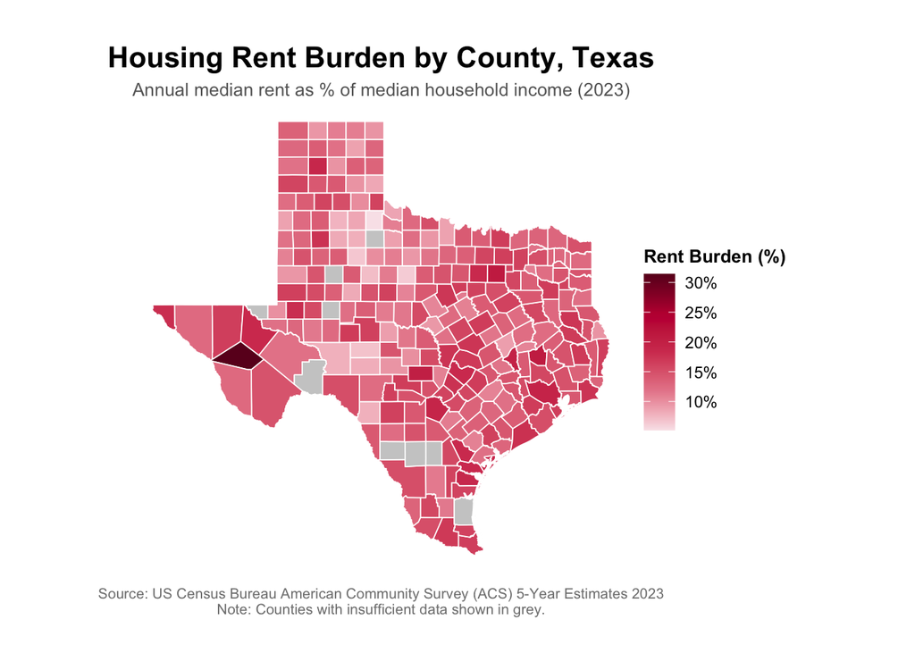

This is another cloropleth map, this time highlighting Texas counties showing rent as a percentage of median household income. **Important Note:** Unfortunately, Ireland does not use median household income as a standard housing metric, and likewise, the United States does not measure disposable income per person (see Figure 1). This is why Irish rent burdens appear higher than Texas rent burdens, partly because individual income is a smaller number than household income. These two cloropleth maps are comparable, but not equivalent to each other.

This map shows how much of a typical household’s income goes toward rent in each of Texas’s 254 counties. The darker the red, the greater the share of income consumed by rent. Unlike Ireland’s map which shows concentration of burden around the Dublin area, Texas is more distributed with rent burden spread across both urban and rural counties, though for very different reasons. In major metros like Harris County (Houston) and Travis County (Austin), high rent driven by population growth and tech industry expansion are the primary culprit. In contrast, many of the deeply shaded rural counties in west and south Texas like Jeff Davis are burdened not because rents are especially high, but because income is quite low. While Ireland and Texas are experiencing housing affordability crises of similar urgency, the geographic results of each crisis is shaped by some different underlying factors.

## Rent Growth Over Time (Ireland vs. Texas Major Metros)

Figure 3

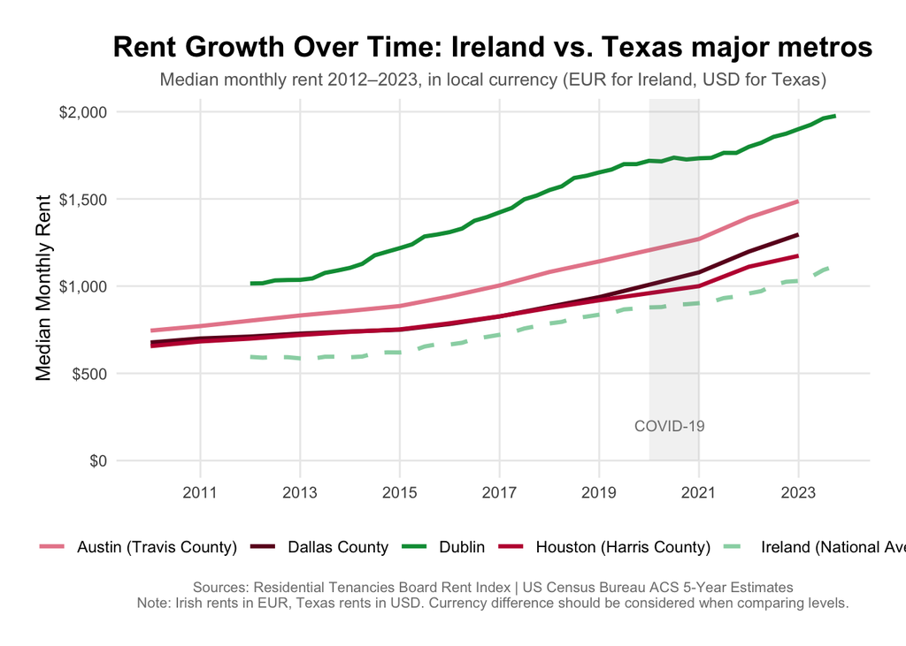

This is a line chart that tracks how median monthly rent has changed over time from 2012 to 2023, comparing Dublin and Ireland’s national average against three of Texas’s major metro counties (Houston, Austin, and Dallas). This chart serves to compare trajectory and rate of rent growth in each region. **Important Note:** Irish rents are displayed in euros, Texas rents are displayed in dollars, and the two aren’t converted to a common currency. The reason is because the euro and dollar have fluctuated against each other significantly over this period. A fixed rate would misrepresent the purchasing power of renters at any given time.

## New Housing Completions vs. Population Growth

Figure 4

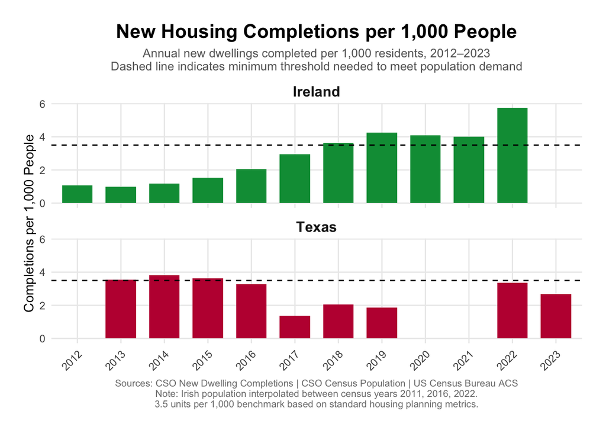

This bar chart shows how many new homes were built per 1,000 residents each year from 2012 to 2023, in separate charts for Ireland and Texas. The dashed black line marks 3.5 new completions per 1,000 people, a widely used planning benchmark that represents the minimum construction rate needed to keep pace with natural population growth, new household formation, and the replacement of aging housing stock (The Urban Institute). Anything below that line means a region is falling further behind on housing supply, and anything above means it is building fast enough to meet demand. **Important Note:** There is no available data for Texas in 2012, 2020, and 2021 and Ireland in 2023.

Ireland’s panel highlights that for the majority of the decade following the 2008 financial crisis, completions collapsed well below that threshold and only began recovering toward the late 2010s, meaning Ireland spent years accumulating a deepening housing deficit that it has never fully recovered from. Ireland rent prices have risen so relentlessly not because of any single policy failure, but because of a decade of under-building that created a structural shortage of homes that the market is still struggling to meet. Texas, by contrast, shows a trend that is very much inverse. The state has generally stayed closer to or above the threshold from 2013 to 2016, before new housing completions could not meet demand around 2017. This is due to an influx of rapid population growth around this time. Only recently has the state begun to bounce back in terms of construction.

## Population Density vs. Rent

Figure 5

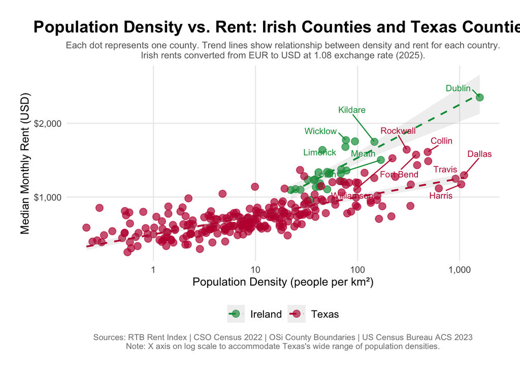

This is a scatterplot that places every Irish county and every Texas county on the same chart, with population density on the horizontal axis and median monthly rent on the vertical axis. Each green dot is an Irish county and each red dot is a Texas county, with Irish rents converted to US dollars for a direct comparison.

**Methodology Note:** Irish rent data sourced from the Residential Tenancies Board Rent Index (RTB), most recent quarter 2025. Irish income data from CSO County Incomes and Regional GDP table CIA02, most recent available year 2019. Texas rent and income data from US Census Bureau American Community Survey 5-Year Estimates, 2023. Irish rents converted to USD at 1.08 EUR/USD (2025 rate) where applicable. County-level income measures differ between countries — Ireland uses disposable income per person while Texas uses median household income — and direct level comparisons should be interpreted accordingly. Irish population interpolated between census years 2011, 2016, and 2022.